# BASIL Reference Standard (Clinical Assessor)

Author

Doug Tommet and Rich Jones for Anna MacKay-Brandt, Tamara G Fong, and the BASIL-II team

Published

May 5, 2025

```
[1] "connected to /Volumes/Research/BM_QuantitativeSciencesPrg/STUDIES/DATA_MANAGEMENT/BASIL"
```

## Aims of manuscript:

1. Describe clinical assessor inter-rater reliability for *delirium severity* ratings:
   1. Overall agreement among clinical assessors
      1. Before consensus meeting *(for generalizability - this is the result that is [more or less] generalizable to other research studies using a single clinical rater for delirium)*
      2. After consensus meeting *(this is the result that describes the reliability of the clinical assessor rating of delirium in the BASIL-II study)*.
   2. Variability in agreement as a function delirium severity (Bland-Altman plots)
2. Explore if there are *delirium features* that are associated with delirium severity inter-rater agreement (e.g., features present include Inattention, Disorganized Thinking, Altered Level of Consciousness, Disorientation, Memory Impairment, Perceptual Disturbances, Psychomotor Agitation, Psychomotor Retardation, Altered Sleep-Wake, Inappropriate Behavior, Delusions).
3. Explore if there are *patient characteristics* that may influence delirium severity inter-rater agreement (e.g., pre-acute cognitive status (NC, MCI, Dementia), three distinct study sites: (1) acute medical inpatients; (2) scheduled surgical inpatients, and (3) long-term and post-acute care residents; informant (family member/friend, nurse, CNA), pre-acute depression)

Note: Aims of manuscript copied from Statistical Analysis Plan ([GDoc](https://docs.google.com/document/d/1GPIzetmxAJxbsQnpXG5_sj9buN0inlTDNljtyg4V1vE/edit?usp=sharing))

## This analysis report (28 Apr 2025)

- The goal of this analysis report is to provide a description of the data for analysis. Variables needed are described in the [SAP](https://docs.google.com/document/d/1GPIzetmxAJxbsQnpXG5_sj9buN0inlTDNljtyg4V1vE/edit?usp=sharing).

Some variables are not yet defined in precise terms, and may warrant discussion:

- **Aim 1 requires**
  - CAM-S scores, before and after consensus, in total BASIL-II sample
  - Indicator for membership in clinical assessor reliability study (n = 46)
  - Separate ratings for pre vs post consensus meeting
  - Characteristics for description of the sample:
    - Age
    - Sex
    - Εducation
    - English as a first language
    - Vision impairment
    - Hearing impairment
    - Depressive symptoms (PHQ)
    - Cognitive performance (MoCA)
    - Dementia (reference standard) *do we mean gold standard? \rnj*
    - AD-8
    - ADL dependence
    - IADL difficulties
    - Delirium (reference standard) *do we mean gold standard? \rnj*
  - Characteristics to model selection into reliability study (*TBD* right now planning on using the factors listed above, but really should be 4-5 predictors)
    - **ACTION**: Need to generate VDSs for ADL and IADL characteristics
    - **ACTION**: Replace REDCap PHQ, MoCA, and AD-8 summary measures with VDS versions
- **Aim 2 additionally requires**
  - Individual delirium features (inattention, disorganized thinking, altered level of consciousness, disorientation, memory impairment, perceptual disturbances, psychomotor agitation, psychomotor retardation, altered sleep-wake, inappropriate behavior, delusions)
    - **ACTION**: Need to modify vds for CAM-S to generate and save individual indicators for the CAM features (0/1)
- **Aim 3 additionally requires**
  - “pre-acute” cognitive status
  - patient group (really, study site) three distinct study sites: (1) acute medical inpatients; (2) scheduled surgical inpatients, and (3) long-term and post-acute care residents
  - informant (family member/friend, nurse, CNA),
  - pre-acute depression

*Note:* **None of the aim 3 variables are pulled**: these need to be defined more precisely (i.e., with respect to REDCap data collected). All I can see in that list that can be consistently measured across site is, `site` itself. \rnj

## This analysis report (02 May 2025)

- Updated handling of delirium severity ratings (0-9), see below
- **ACTION**: Need to generate VDSs for ADL and IADL characteristics
- **ACTION**: Replace REDCap PHQ, MoCA, and AD-8 summary measures with VDS versions
- **ACTION** Aim 2 additionally requires individual CAM-S delirium features (inattention, disorganized thinking, altered level of consciousness, disorientation, memory impairment, perceptual disturbances, psychomotor agitation, psychomotor retardation, altered sleep-wake, inappropriate behavior, delusions), need to modify vds for CAM-S to generate and save individual indicators for the CAM features (0/1)

## Data handling notes

**RS ratings and their updates given consensus**

We assume that when a rating appears with an arrow, e.g, “9 -> 6”, this means that the rating was updated from 9 to 6 after the consensus process.

**Dementia severity ratings**

RS adjudication dementia severity categories were provided as 5 text labels. We have ordered these into 5 numeric categories with the following ordering (see `new_order`):

| Freq. | Numeric | New Order | Labels provided |
| --- | --- | --- | --- |
| 79 | 3 | 0 | no dementia (equivalent to no neurocognitive disorder) |
| 81 | 5 | 1 | very mild (equivalent to minor neurocognitive disorder) |
| 89 | 1 | 2 | mild |
| 63 | 2 | 3 | moderate |
| 8 | 4 | 4 | severe |

Note: `Freq`-uency is the number of 320 adjudcations among 46 participants. `Numeric` is the oder assigned to the provided text labels in `Labels provided`, and are sorted alphabetically. `New Order` is the order we have assigned to the numeric labels, and is used in the analysis.

**Codebook listing**

```
------------------------------------------------------------------------------------
studyid                                                                  (unlabeled)
------------------------------------------------------------------------------------

                  Type: String (str7)

         Unique values: 46                        Missing "": 0/320

              Examples: "DB43364"
                        "TN60081"
                        "TN60363"
                        "UF50103"

------------------------------------------------------------------------------------
rsadjname                                                                Adjudicator
------------------------------------------------------------------------------------

                  Type: String (str20)

         Unique values: 7                         Missing "": 0/320

            Tabulation: Freq.  Value
                           46  "Anna MacKay-Brandt"
                           46  "Benjamin Chapin"
                           46  "Cate Price"
                           46  "Juliana Burt"
                           46  "Kerry Palihnich"
                           44  "Rebecca Avila-Rieger"
                           46  "Wingyun Mak"

               Warning: Variable has embedded blanks.

------------------------------------------------------------------------------------
rsadjdate                                                                       Date
------------------------------------------------------------------------------------

                  Type: Numeric daily date (int)

                 Range: [23408,23621]                 Units: 1
       Or equivalently: [02feb2024,02sep2024]         Units: days
```

[output cut: 50 more lines]

```

------------------------------------------------------------------------------------
deliriumseverity_2n                                    Delirium Severity (consensus)
------------------------------------------------------------------------------------

                  Type: Numeric (long)
                 Label: deliriumseverity_2n

                 Range: [1,13]                        Units: 1
         Unique values: 13                        Missing .: 0/320

              Examples: 1     0
                        2     1
                        5     4
                        9     6
```

**Question(s)** Is the 1-13 scale really correct? These are CAM-S scores? CAM-S scores do potentially range from 0-19, with 19 being the most severe.

```
------------------------------------------------------------------------------------
ncdpresence_1n                                                NCD Presence (initial)
------------------------------------------------------------------------------------

                  Type: Numeric (long)
                 Label: ncd_status

                 Range: [1,3]                         Units: 1
         Unique values: 3                         Missing .: 0/320

            Tabulation: Freq.   Numeric  Label
                           80         1  no NCD
                           84         2  Minor NCD
                          156         3  Major NCD

------------------------------------------------------------------------------------
ncdpresence_2n                                              NCD Presence (consensus)
------------------------------------------------------------------------------------

                  Type: Numeric (long)
                 Label: ncd_status

                 Range: [1,3]                         Units: 1
         Unique values: 3                         Missing .: 0/320

            Tabulation: Freq.   Numeric  Label
                           76         1  no NCD
                           78         2  Minor NCD
                          166         3  Major NCD

------------------------------------------------------------------------------------
dementiaseverity_1n                                      Dementia Severity (initial)
------------------------------------------------------------------------------------

                  Type: Numeric (long)
                 Label: cogn_status

                 Range: [0,4]                         Units: 1
         Unique values: 5                         Missing .: 0/320

```

[output cut: 8 more lines]

```
dementiaseverity_2n                                    Dementia Severity (consensus)
------------------------------------------------------------------------------------

                  Type: Numeric (long)
                 Label: cogn_status

                 Range: [0,4]                         Units: 1
         Unique values: 5                         Missing .: 0/320

            Tabulation: Freq.   Numeric  Label
                           76         0  no dementia
                           77         1  very mild (Minor NCD)
                          100         2  mild
                           57         3  moderate
                           10         4  severe
```

```
    Variable        |        Obs       Mean    sd       Min        Max
--------------------+---------------------------------------------------------
deliriumpresence_1n |        320       1.44    .50       1          2
deliriumpresence_2n |        320       1.45    .50       1          2
--------------------+---------------------------------------------------------
dementiaseverity_1n |        320       4.09    3.13      1         11
dementiaseverity_2n |        320       4.44    3.59      1         13
--------------------+---------------------------------------------------------
ncdpresence_1n      |        320       2.25    .83       1          3
ncdpresence_2n      |        320       2.28    .82       1          3
--------------------+---------------------------------------------------------
dementiaseverity_1n |        320       1.50    1.14      0          4
dementiaseverity_2n |        320       1.53    1.13      0          4
```

# Table 1

Table 1: Descriptive statistics of the RS sample

| **Characteristic** | **Overall** N = 46<sup>1</sup> | **1** N = 10<sup>1</sup> | **2** N = 14<sup>1</sup> | **3** N = 22<sup>1</sup> |
| --- | --- | --- | --- | --- |
| Age | 80.0 (6.2) | 80.1 (7.2) | 77.4 (3.9) | 81.5 (6.7) |
| Female Sex |  |  |  |  |
| Male | 19 (41%) | 4 (40%) | 7 (50%) | 8 (36%) |
| Female | 27 (59%) | 6 (60%) | 7 (50%) | 14 (64%) |
| Education | 14.3 (3.2) | 14.5 (2.7) | 14.7 (2.6) | 14.0 (3.7) |
| Unknown | 1 | 0 | 0 | 1 |
| Hispanic ethnicity |  |  |  |  |
| Not Hispanic | 46 (100%) | 10 (100%) | 14 (100%) | 22 (100%) |
| Hispanic | 0 (0%) | 0 (0%) | 0 (0%) | 0 (0%) |
| English is second language | 1 (2.2%) | 0 (0%) | 0 (0%) | 1 (4.5%) |
| Vision impairment | 16 (39%) | 2 (20%) | 3 (21%) | 11 (65%) |
| Unknown | 5 | 0 | 0 | 5 |
| Hearing impairment | 14 (30%) | 2 (20%) | 4 (29%) | 8 (36%) |
| Charlson Comorbidity Index |  |  |  |  |
| 0 | 11 (24%) | 2 (20%) | 4 (31%) | 5 (23%) |
| 1 | 3 (6.7%) | 1 (10%) | 2 (15%) | 0 (0%) |
| 2 | 10 (22%) | 2 (20%) | 3 (23%) | 5 (23%) |
| 3 | 6 (13%) | 2 (20%) | 2 (15%) | 2 (9.1%) |
| 4 | 4 (8.9%) | 0 (0%) | 0 (0%) | 4 (18%) |
| 5 | 6 (13%) | 2 (20%) | 1 (7.7%) | 3 (14%) |
| 8 | 5 (11%) | 1 (10%) | 1 (7.7%) | 3 (14%) |
| Unknown | 1 | 0 | 1 | 0 |
| Major neurocognitive disorder (GS) | 27 (59%) | 3 (30%) | 3 (21%) | 21 (95%) |
| Minor neurocognitive disorder (GS) | 9 (20%) | 5 (50%) | 3 (21%) | 1 (4.5%) |
| Delirium diagnosis (GS) | 21 (46%) | 6 (60%) | 6 (43%) | 9 (41%) |
| vdcamsrs | 3.22 (2.60) | 4.20 (2.82) | 0.71 (0.73) | 4.36 (2.17) |
| PHQ-9 score | 5.5 (3.8) | 5.6 (2.7) | 4.9 (2.7) | 5.9 (4.7) |
| MOCA score | 17 (6) | 20 (5) | 18 (6) | 14 (6) |
| AD8 total score |  |  |  |  |
| 0 | 25 (54%) | 4 (40%) | 8 (57%) | 13 (59%) |
| 1 | 4 (8.7%) | 1 (10%) | 2 (14%) | 1 (4.5%) |
| 2 | 8 (17%) | 2 (20%) | 2 (14%) | 4 (18%) |
| 3 | 2 (4.3%) | 0 (0%) | 1 (7.1%) | 1 (4.5%) |
| 4 | 3 (6.5%) | 1 (10%) | 0 (0%) | 2 (9.1%) |
| 5 | 1 (2.2%) | 0 (0%) | 0 (0%) | 1 (4.5%) |
| 7 | 2 (4.3%) | 2 (20%) | 0 (0%) | 0 (0%) |
| 8 | 1 (2.2%) | 0 (0%) | 1 (7.1%) | 0 (0%) |

<sup>1</sup> Mean (SD); n (%)

|  | delirium_severity_B 0 | delirium_severity_B 1 | delirium_severity_B 2 | delirium_severity_B 3 | delirium_severity_B 4 | delirium_severity_B 5 | delirium_severity_B 6 | delirium_severity_B 7 | delirium_severity_B 8 | delirium_severity_B 9 | delirium_severity_B Unknown | Total |  |
| --- | --- | --- | --- | --- | --- | --- | --- | --- | --- | --- | --- | --- | --- |
| delirium_severity_A |  |  |  |  |  |  |  |  |  |  |  |  |  |
| 0 | 218 | 60 | 7 | 14 | 14 | 0 | 0 | 0 | 0 | 0 | 2 | 315 |  |
| 1 | 57 | 31 | 7 | 6 | 12 | 1 | 1 | 0 | 0 | 0 | 2 | 117 |  |
| 2 | 40 | 19 | 5 | 7 | 5 | 0 | 0 | 0 | 0 | 0 | 1 | 77 |  |
| 3 | 18 | 17 | 5 | 2 | 12 | 4 | 1 | 0 | 0 | 0 | 1 | 60 |  |
| 4 | 2 | 7 | 1 | 7 | 24 | 22 | 14 | 3 | 0 | 0 | 4 | 84 |  |
| 5 | 3 | 7 | 0 | 8 | 18 | 36 | 27 | 16 | 0 | 0 | 0 | 115 |  |
| 6 | 0 | 0 | 0 | 3 | 4 | 30 | 21 | 19 | 1 | 4 | 0 | 82 |  |
| 7 | 0 | 0 | 0 | 1 | 7 | 17 | 22 | 13 | 2 | 0 | 0 | 62 |  |
| 8 | 0 | 0 | 0 | 0 | 0 | 3 | 6 | 2 | 7 | 5 | 0 | 23 |  |
| 9 | 0 | 0 | 0 | 0 | 0 | 5 | 6 | 5 | 9 | 4 | 0 | 29 |  |
| Unknown | 1 | 0 | 0 | 0 | 0 | 1 | 0 | 0 | 0 | 0 | 0 | 2 |  |
| Total | 339 | 141 | 25 | 48 | 96 | 119 | 98 | 58 | 19 | 13 | 10 | 966 |  |

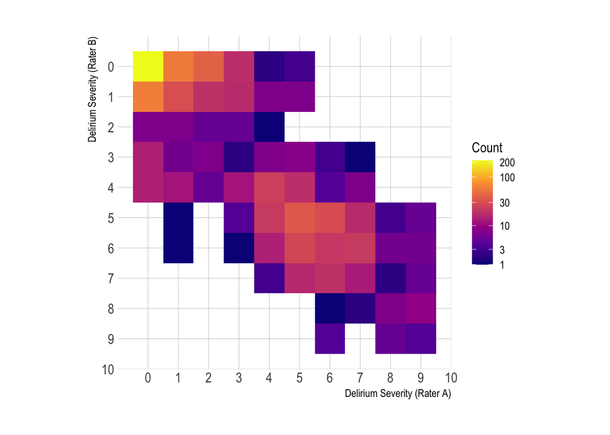

Figure 1: Heatmap showing agreement of paired initial ratings of delirium severity

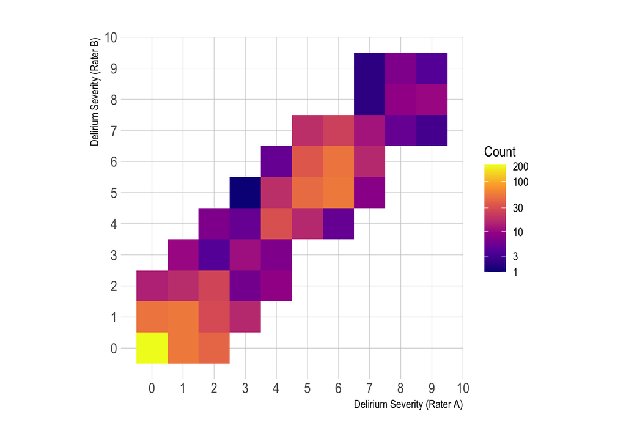

Figure 2: Heatmap showing agreement of paired ratings of delirium severity after consensus process